# Analyzing Individual BGG Users

Phil Henrickson

2022-01-01

# **Beardlessbrady’s** BoardGameGeek Collection

This notebook contains a set of analyses for the selected user’s boardgamegeek collection. The bulk of the analysis is focused on building a user-specific predictive model to predict the games that Beardlessbrady is likely to own. This enables to ask questions like, based on the games the user currently owns, what games are a good fit for their collection? What upcoming games are they likely to purchase?

This analysis is based on data from BoardGameGeek that was last updated on **2021-12-20.**

# 1 Collection Overview

We can look at a basic description of the number of games that the user owns, has rated, has previously owned, etc.

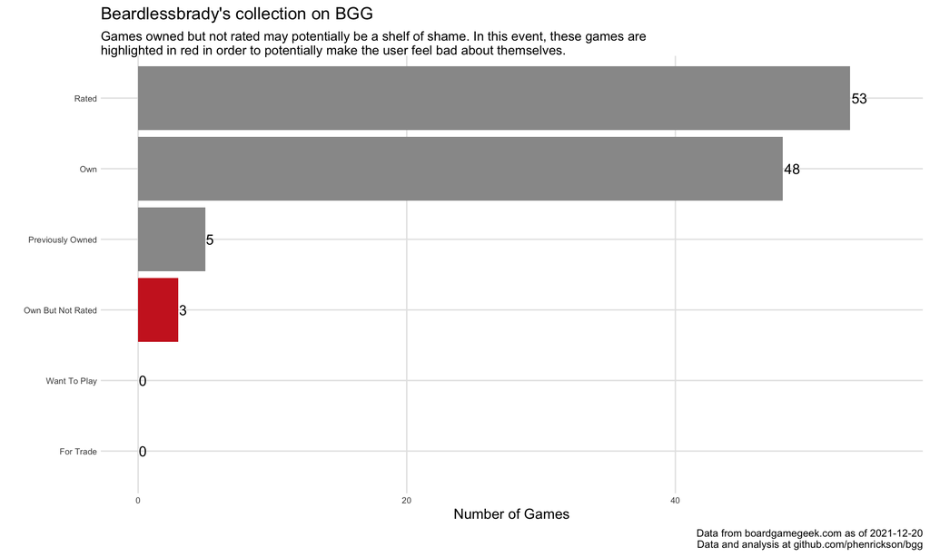

What years has the user owned/rated games from? While we can’t see when a user added or removed a game from their collection, we can look at their collection by the years in which their games were published.

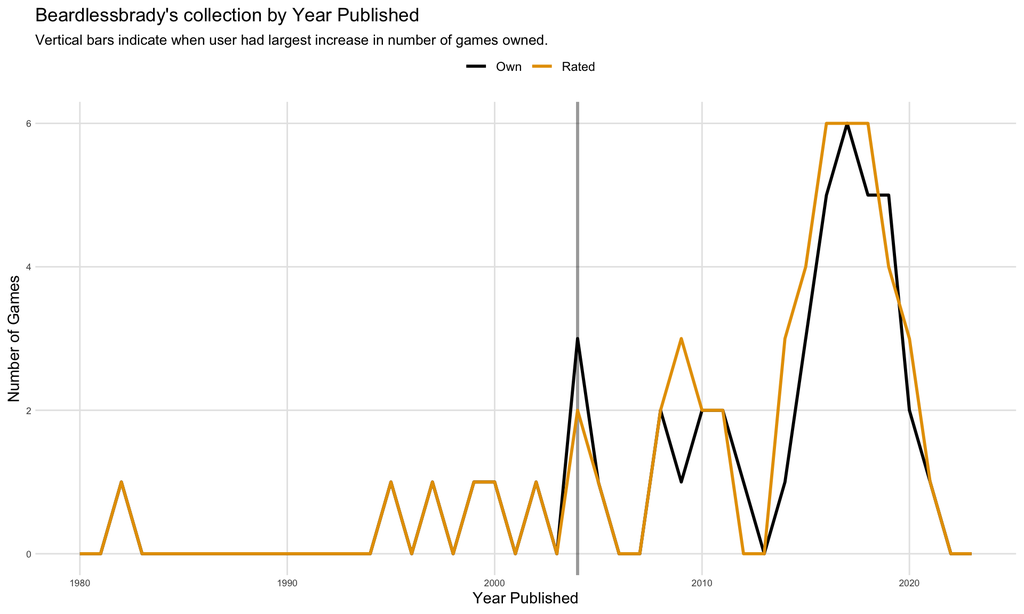

## 1.1 What types of games does Beardlessbrady own?

We can look at the most frequent types of categories, mechanics, designers, and artists that appear in a user’s collection.

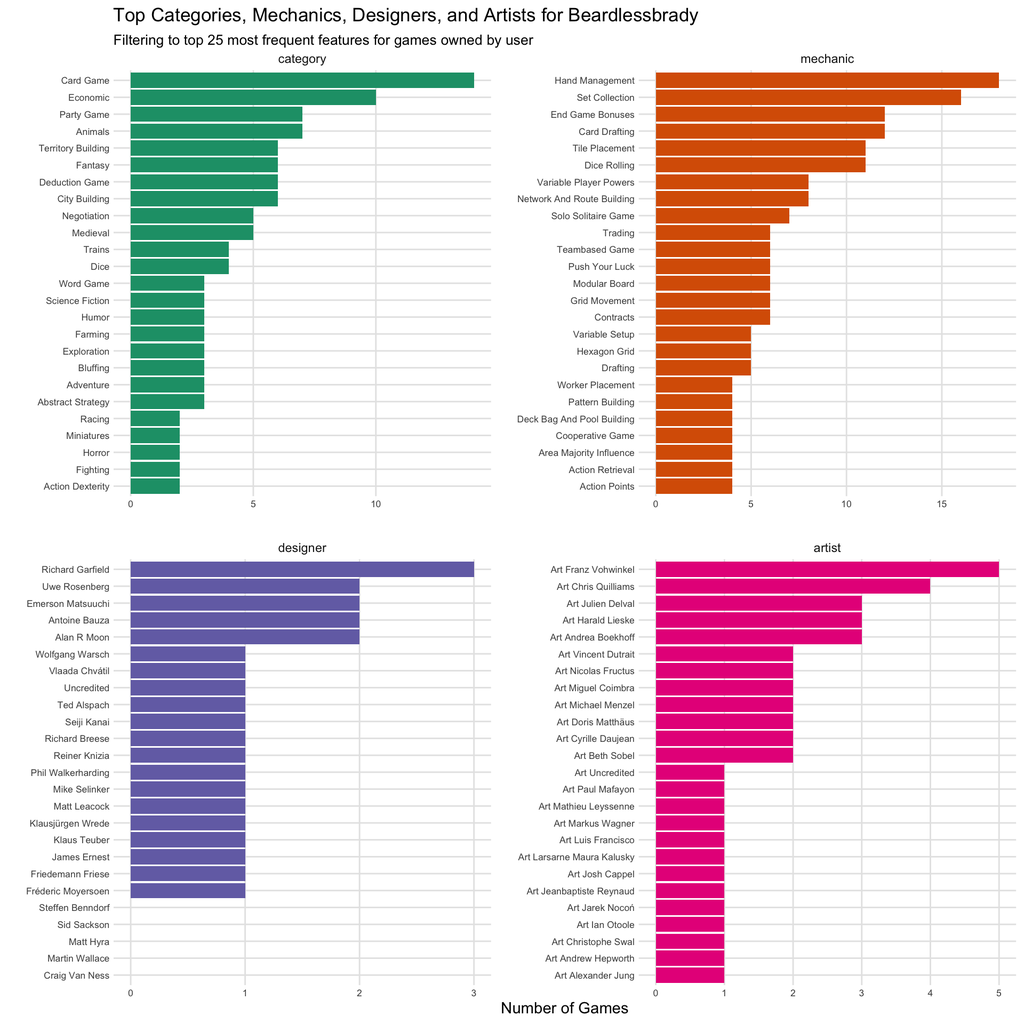

# 2 Modeling **Beardlessbrady’s** Collection

| username | dataset | period | games_owned | games_rated | games_played |
| --- | --- | --- | --- | --- | --- |
| Beardlessbrady | training | published before 2020 | 45 | 49 | 52 |
| Beardlessbrady | test | published 2020 or later | 3 | 4 | 4 |

There are two main (binary) outcomes we will be modeling for the user.

The first, **own** refers to whether the user currently lists a game as owned in their collection. The second, **played** refers to whether the user currently owns, has rated, or previously owned a game. This means the latter will generally have a larger list of games, but may still be a useful category to examine for people who play lots of games without necessarily owning them.

We will train predictive models to learn the probability that the user will own or play individual games based on their features.

## 2.1 Coefficients for Beardlessbrady

We can examine coefficients from the trained modes, which are penalized logistic regressions fit to our two main outcomes. Positive values indicate that a feature increases a user’s probabilility of owning/rating a game, while negative values indicate a feature decreases the probability.

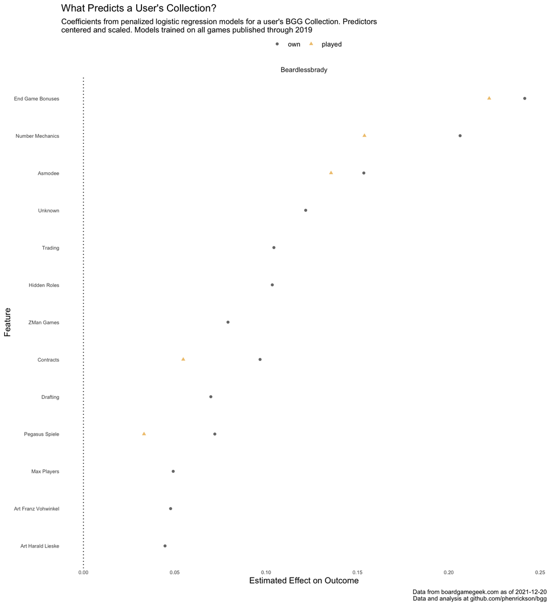

## 2.2 Visualizing Predictors for Beardlessbrady’s Collection

Why did the model identify these features? We can make density plots of the important features for predicting whether the user owned a game. Blue indicates the density for games owned by the user, while grey indicates the density for games not owned by the user.

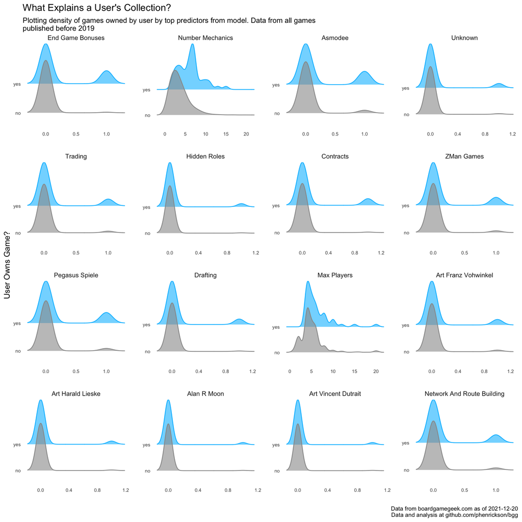

Binary predictors can be difficult to see with this visualization, so we can also directly examine the percentage of games in a user’s collection with a predictor vs the percentage of all games with that predictor.

| username | Feature | % of Games with Feature In_Collection | % of Games with Feature All_Games | Ratio |
| --- | --- | --- | --- | --- |
| Beardlessbrady | End Game Bonuses | 24.4% | 1.2% | 21.0 |
| Beardlessbrady | Contracts | 13.3% | 1.0% | 13.7 |
| Beardlessbrady | Drafting | 11.1% | 1.0% | 11.1 |
| Beardlessbrady | Hidden Roles | 6.7% | 0.7% | 9.5 |
| Beardlessbrady | Unknown | 8.9% | 1.5% | 6.1 |
| Beardlessbrady | Asmodee | 24.4% | 5.3% | 4.6 |
| Beardlessbrady | ZMan Games | 15.6% | 3.5% | 4.5 |
| Beardlessbrady | Alderac Entertainment Group | 6.7% | 1.5% | 4.3 |
| Beardlessbrady | Trading | 13.3% | 3.2% | 4.2 |
| Beardlessbrady | Pegasus Spiele | 20.0% | 4.7% | 4.2 |
| Beardlessbrady | Network And Route Building | 15.6% | 4.1% | 3.8 |
| Beardlessbrady | Word Game | 6.7% | 1.7% | 3.8 |
| Beardlessbrady | Territory Building | 13.3% | 3.6% | 3.7 |
| Beardlessbrady | Negotiation | 11.1% | 3.6% | 3.1 |
| Beardlessbrady | City Building | 13.3% | 4.2% | 3.1 |
| Beardlessbrady | Trains | 6.7% | 2.2% | 3.1 |
| Beardlessbrady | Prehistoric | 2.2% | 1.0% | 2.2 |
| Beardlessbrady | Party Game | 15.6% | 8.4% | 1.8 |
| Beardlessbrady | Medieval | 11.1% | 6.3% | 1.8 |
| Beardlessbrady | Racing | 4.4% | 2.8% | 1.6 |
| Beardlessbrady | Horror | 4.4% | 4.0% | 1.1 |
| Beardlessbrady | Action Dexterity | 4.4% | 4.8% | 0.9 |
| Beardlessbrady | Puzzle | 2.2% | 3.4% | 0.7 |
| Beardlessbrady | Trivia | 0.0% | 1.8% | 0.0 |
| Beardlessbrady | Mafia | 0.0% | 0.7% | 0.0 |

# 3 Assess Model’s Performance on Training Set

Before predicting games in upcoming years, we can examine how well the model did and what games it liked in the training set. In this case, we used resampling techniques (cross validation) to ensure that the model had not seen a game before making its predictions.

## 3.1 Separation Plot

An easy way to examine the performance of classification model is to view a separation plot. We plot the predicted probabilities from the model for every game (from resampling) from lowest to highest. We then overlay a blue line for any game that the user does own. A good classifier is one that is able to *separate* the blue (games owned by the user) from the white (games not owned by the user), with most of the blue occurring at the highest probabilities (right side of the chart).

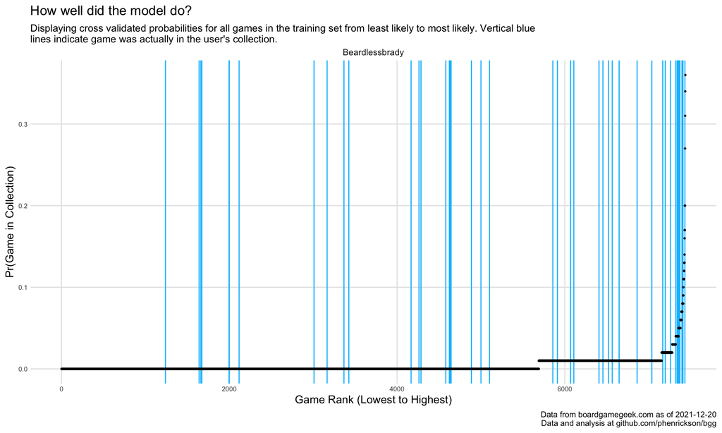

## 3.2 Top Games for **Beardlessbrady** from Training Set

We can display this information in table form, displaying the 100 games with the highest probability of ownership, adding a blue line when the user does own the game.

| username | yearpublished | game_id | name | pred_played | pred_own | actual_played | actual_own |
| --- | --- | --- | --- | --- | --- | --- | --- |
| Beardlessbrady | 2018 | 205896 | Rising Sun | 0.32 | 0.36 | 0 | 0 |
| Beardlessbrady | 2019 | 260710 | Amul | 0.22 | 0.34 | 0 | 0 |
| Beardlessbrady | 2019 | 283863 | The Magnificent | 0.30 | 0.31 | 0 | 0 |
| Beardlessbrady | 2019 | 270971 | Era: Medieval Age | 0.05 | 0.27 | 0 | 0 |
| Beardlessbrady | 2011 | 70919 | Takenoko | 0.04 | 0.20 | 1 | 1 |
| Beardlessbrady | 2012 | 131357 | Coup | 0.03 | 0.20 | 0 | 0 |
| Beardlessbrady | 2016 | 177590 | 13 Days: The Cuban Missile Crisis | 0.04 | 0.17 | 0 | 0 |
| Beardlessbrady | 2019 | 251247 | Barrage | 0.10 | 0.17 | 0 | 0 |
| Beardlessbrady | 2015 | 181687 | The Pursuit of Happiness | 0.09 | 0.16 | 0 | 0 |
| Beardlessbrady | 2012 | 120677 | Terra Mystica | 0.08 | 0.14 | 0 | 0 |
| Beardlessbrady | 2016 | 176083 | Hit Z Road | 0.12 | 0.13 | 0 | 0 |
| Beardlessbrady | 2017 | 218603 | Photosynthesis | 0.12 | 0.13 | 0 | 0 |
| Beardlessbrady | 2018 | 256226 | Azul: Stained Glass of Sintra | 0.03 | 0.13 | 0 | 0 |
| Beardlessbrady | 2018 | 244711 | Newton | 0.12 | 0.12 | 0 | 0 |
| Beardlessbrady | 2019 | 261342 | Old West Empresario | 0.03 | 0.12 | 0 | 0 |
| Beardlessbrady | 2000 | 478 | Citadels | 0.03 | 0.12 | 0 | 0 |
| Beardlessbrady | 2016 | 196340 | Yokohama | 0.08 | 0.11 | 0 | 0 |
| Beardlessbrady | 2019 | 240567 | Chocolate Factory | 0.10 | 0.11 | 0 | 0 |
| Beardlessbrady | 2015 | 160744 | Far Space Foundry | 0.10 | 0.11 | 0 | 0 |
| Beardlessbrady | 2017 | 230802 | Azul | 0.05 | 0.11 | 0 | 0 |
| Beardlessbrady | 2019 | 256730 | Pipeline | 0.09 | 0.11 | 0 | 0 |
| Beardlessbrady | 2019 | 253635 | Ragusa | 0.09 | 0.11 | 0 | 0 |
| Beardlessbrady | 2017 | 217861 | Paper Tales | 0.11 | 0.11 | 0 | 0 |
| Beardlessbrady | 2016 | 167791 | Terraforming Mars | 0.08 | 0.11 | 0 | 0 |
| Beardlessbrady | 2019 | 266507 | Clank!: Legacy – Acquisitions Incorporated | 0.11 | 0.10 | 0 | 0 |
| Beardlessbrady | 2009 | 55600 | Shipyard | 0.11 | 0.09 | 0 | 0 |
| Beardlessbrady | 2005 | 18258 | Mission: Red Planet | 0.04 | 0.09 | 0 | 0 |
| Beardlessbrady | 2014 | 157354 | Five Tribes | 0.08 | 0.08 | 0 | 0 |
| Beardlessbrady | 2017 | 220308 | Gaia Project | 0.03 | 0.08 | 0 | 0 |
| Beardlessbrady | 2016 | 185589 | Islebound | 0.07 | 0.08 | 0 | 0 |

[output cut: 70 more lines]

We can also more formally assess how well the model did in resampling by looking at the area under the receiver operating characteristic. A perfect model would receive a score of 1, while a model that cannot predict the outcome will default to a score of 0.5. The extent to which something is a *good* score depends on the setting, but generally anything in the .8 to .9 range is very good while the .7 to .8 range is perfectly acceptable.

| username | outcome_type | .metric | .estimator | .estimate |
| --- | --- | --- | --- | --- |
| Beardlessbrady | own | roc_auc | binary | 0.745 |
| Beardlessbrady | played | roc_auc | binary | 0.758 |

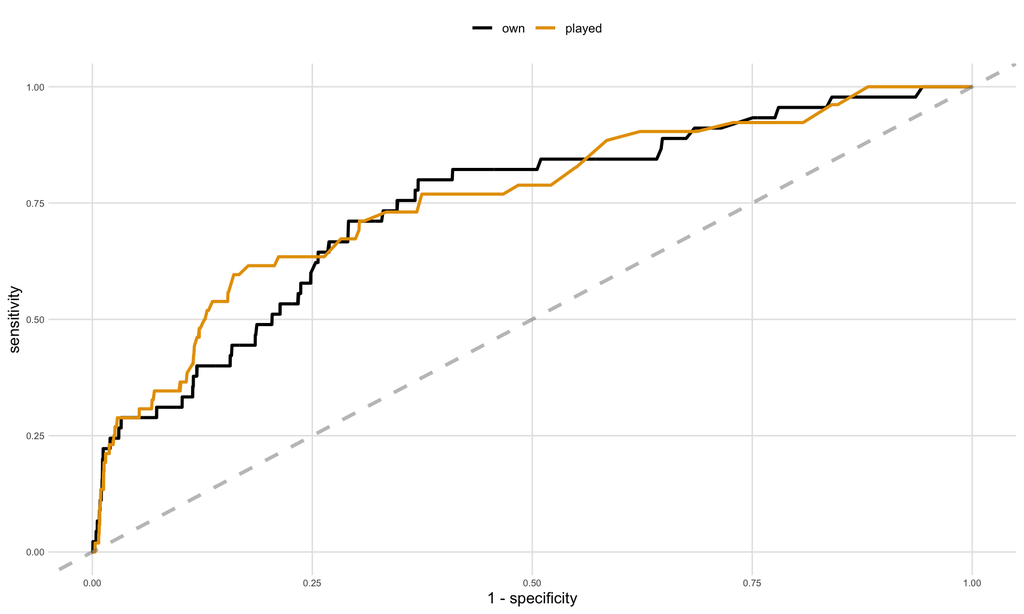

Another way to think about the model performance is to view its lift, or its ability to detect the positive outcomes over that of a null model. High lift indicates the model can much more quickly find all of the positive outcomes (in this case, games owned or played by the user), while a model with no lift is no better than random guessing.

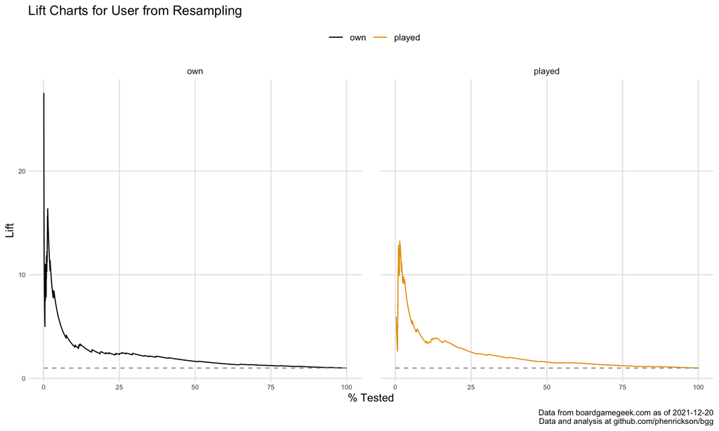

## 3.3 Most and Least Likely Games

What games does the model think Beardlessbrady is **most likely to own** that are **not** in their collection?

| username | yearpublished | game_id | name | pred_own | actual_own |
| --- | --- | --- | --- | --- | --- |
| Beardlessbrady | 2018 | 205896 | Rising Sun | 0.36 | 0 |
| Beardlessbrady | 2019 | 260710 | Amul | 0.34 | 0 |
| Beardlessbrady | 2019 | 283863 | The Magnificent | 0.31 | 0 |
| Beardlessbrady | 2019 | 270971 | Era: Medieval Age | 0.27 | 0 |
| Beardlessbrady | 2012 | 131357 | Coup | 0.20 | 0 |

What games does the model think Beardlessbrady is **least likely to own** that **are** in their collection?

| username | yearpublished | game_id | name | pred_own | actual_own |
| --- | --- | --- | --- | --- | --- |
| Beardlessbrady | 2015 | 55690 | Kingdom Death: Monster | 0 | 1 |
| Beardlessbrady | 2017 | 217372 | The Quest for El Dorado | 0 | 1 |
| Beardlessbrady | 2017 | 233678 | Indian Summer | 0 | 1 |
| Beardlessbrady | 2018 | 244608 | Menara | 0 | 1 |
| Beardlessbrady | 2018 | 242574 | Century: Eastern Wonders | 0 | 1 |

## 3.4 Top Games by Year

Top 25 games most likely to be owned by the user in each year, highlighting in blue the games that the user has owned/played.

| rank | 2011 | 2012 | 2013 | 2014 | 2015 | 2016 | 2017 | 2018 | 2019 |
| --- | --- | --- | --- | --- | --- | --- | --- | --- | --- |
| 1 | Takenoko | Coup | Legacy: The Testament of Duke de Crecy | Five Tribes | The Pursuit of Happiness | 13 Days: The Cuban Missile Crisis | Photosynthesis | Rising Sun | Amul |
| 2 | Discworld: Ankh-Morpork | Terra Mystica | BANG! The Dice Game | Camel Up | Far Space Foundry | Hit Z Road | Azul | Azul: Stained Glass of Sintra | The Magnificent |
| 3 | Mage Knight Board Game | Lords of Waterdeep | Sushi Go! | Ultimate Werewolf | Grand Austria Hotel | Yokohama | Paper Tales | Newton | Era: Medieval Age |
| 4 | The Castles of Burgundy | Targi | Russian Railroads | Imperial Settlers | Mega Civilization | Terraforming Mars | Gaia Project | Everdell | Barrage |
| 5 | Village | Robinson Crusoe: Adventures on the Cursed Island | Mascarade | La Granja | Tiny Epic Galaxies | Islebound | Calimala | Kero | Old West Empresario |
| 6 | The Secret of Monte Cristo | Keyflower | Circus Train (Second Edition) | Istanbul | Haspelknecht | Sushi Go Party! | Bunny Kingdom | Coimbra | Chocolate Factory |
| 7 | Mundus Novus | Suburbia | Room 25 | Castles of Mad King Ludwig | Blood Rage | The Networks | Gloomhaven | Western Legends | Pipeline |
| 8 | Undermining | Il Vecchio | Brew Crafters | Alchemists | The Bloody Inn | Avenue | The Chameleon | Underwater Cities | Ragusa |
| 9 | A Few Acres of Snow | Kairo | Lewis & Clark: The Expedition | Deception: Murder in Hong Kong | 504 | Pandemic: Reign of Cthulhu | Richard the Lionheart | Pax Emancipation | Clank!: Legacy – Acquisitions Incorporated |
| 10 | Ascension: Return of the Fallen | Tzolk'in: The Mayan Calendar | Pathfinder Adventure Card Game: Rise of the Runelords – Base Set | Spurs: A Tale in the Old West | The Voyages of Marco Polo | New Angeles | Twilight Imperium: Fourth Edition | Nemesis | Maracaibo |
| 11 | Friday | Clash of Cultures | A Study in Emerald | Splendor | A Study in Emerald (Second Edition) | Dynasties: Heirate & Herrsche | One Night Ultimate Alien | Blue Lagoon | Sierra West |
| 12 | Martian Dice | Santa Cruz | Smash Up: Awesome Level 9000 | Legendary Encounters: An Alien Deck Building Game | Raptor | Pandemic: Iberia | Werewords | Gingerbread House | Minecraft: Builders & Biomes |
| 13 | Ventura | The Resistance: Avalon | Hoplomachus: Rise of Rome | North Wind | Elysium | The Manhattan Project: Energy Empire | Smash Up: What Were We Thinking? | Hail Hydra | Azul: Summer Pavilion |
| 14 | Pantheon | Tokaido | Agent Hunter | Sheep & Thief | Mysterium | Scythe | Tortuga 1667 | Human Punishment: Social Deduction 2.0 | Pandemic: Rapid Response |
| 15 | Dungeon Petz | Star Trek: Catan | Colonialism | Good Cop Bad Cop | One Night Ultimate Werewolf: Daybreak | Clank!: A Deck-Building Adventure | Sagrada | The World of SMOG: Rise of Moloch | Wingspan |
| 16 | Helvetia | Seasons | BioShock Infinite: The Siege of Columbia | Secret Moon | One Night Revolution | Imhotep | Majesty: For the Realm | Sprawlopolis | It's a Wonderful World |
| 17 | The Gnomes of Zavandor | Smash Up | City of Remnants | [redacted] | One Night Ultimate Vampire | Citadels | Breaking Bad: The Board Game | Pandemic: Fall of Rome | Crystal Palace |
| 18 | Feudalia | One Night Werewolf | Amerigo | Colt Express | Exploding Kittens: NSFW Deck | Thief's Market | This War of Mine: The Board Game | Treasure Island | Century: A New World |
| 19 | Gears of War: The Board Game | Space Cadets | Theseus: The Dark Orbit | Templar Intrigue | Smash Up: Pretty Pretty Smash Up | Inis | Massive Darkness | A Song of Ice & Fire: Tabletop Miniatures Game – Stark vs Lannister Starter Set | Silver & Gold |
| 20 | Ora et Labora | The Manhattan Project | Warhammer: Diskwars | Praetor | Haleakala | Roll Player | Quests of Valeria | Smash Up: That '70s Expansion | Tiny Towns |
| 21 | Space Empires: 4X | Mage Wars Arena | Glass Road | Roll for the Galaxy | Sylvion | Captain Sonar | Kingsburg (Second Edition) | Duelosaur Island | Hadara |
| 22 | Ascending Empires | Kingdom of Heaven: The Crusader States 1097-1291 | Coal Baron | Gaïa | Obama Llama | Timebomb | LYNGK | Smash Up: Oops, You Did It Again | Q.E. |
| 23 | Santiago de Cuba | Pocket Battles: Macedonians vs. Persians | Eight-Minute Empire: Legends | Heroes of Normandie | Chaosmos | Insider | Smash Up: Big in Japan | Fort Sumter: The Secession Crisis, 1860-61 | De Vulgari Eloquentia: Deluxe Edition |
| 24 | Spectral Rails | Agricola: All Creatures Big and Small | Berserk: War of the Realms | Smash Up: Science Fiction Double Feature | T.I.M.E Stories | Broom Service: The Card Game | Codenames: Duet | Prowler's Passage | The Isle of Cats |
| 25 | Ninjato | Pixel Tactics | Sail to India | Pagoda | My Village | Secret Hitler | Tesla vs. Edison: Duel | Arkham Noir: Case #2 – Called Forth By Thunder | Marco Polo II: In the Service of the Khan |

## 3.5 Interactive Predictions from Resampling

Interactive table for predictions from resampling.

|  | username | yearpublished | rank | game_id | name | pred_played | pred_own | actual_played | actual_own |
| --- | --- | --- | --- | --- | --- | --- | --- | --- | --- |
| 1 | Beardlessbrady | 1900 | 157 | 2393 | Xiangqi | 0.01 | 0.02 | 0 | 0 |
| 2 | Beardlessbrady | 1900 | 160 | 2397 | Backgammon | 0.01 | 0.02 | 0 | 0 |
| 3 | Beardlessbrady | 1900 | 163 | 10213 | Fox and Geese | 0.01 | 0.02 | 0 | 0 |
| 4 | Beardlessbrady | 1900 | 165 | 11929 | Go-Moku | 0 | 0.02 | 0 | 0 |
| 5 | Beardlessbrady | 1900 | 168 | 7316 | Bingo | 0.01 | 0.02 | 0 | 0 |
| 6 | Beardlessbrady | 1900 | 219 | 6887 | Hearts | 0.01 | 0.02 | 0 | 0 |
| 7 | Beardlessbrady | 1900 | 238 | 2386 | Chinese Checkers | 0.01 | 0.02 | 0 | 0 |
| 8 | Beardlessbrady | 1900 | 248 | 11670 | The Game of Authors | 0.01 | 0.02 | 0 | 0 |
| 9 | Beardlessbrady | 1900 | 254 | 2394 | Dominoes | 0.01 | 0.02 | 0 | 0 |
| 10 | Beardlessbrady | 1900 | 289 | 188 | Go | 0.01 | 0.01 | 0 | 0 |

[output cut: 7426 more lines]

# 4 Validating the Model on 2020

How well did a model trained on a user’s collection through 2019 perform in predicting games for the user from 2020?

| username | outcome_type | yearpublished | .metric | .estimator | .estimate |
| --- | --- | --- | --- | --- | --- |
| Beardlessbrady | own | 2020 | roc_auc | binary | 0.173 |
| Beardlessbrady | played | 2020 | roc_auc | binary | 0.194 |

Table of top 25 games from 2020, highlighting games that the user owns.

| username | yearpublished | game_id | name | pred_own | pred_played | actual_own | actual_played |
| --- | --- | --- | --- | --- | --- | --- | --- |
| Beardlessbrady | 2020 | 184267 | On Mars | 0.35 | 0.15 | 0 | 0 |
| Beardlessbrady | 2020 | 307844 | Atheneum: Mystic Library | 0.16 | 0.08 | 0 | 0 |
| Beardlessbrady | 2020 | 300322 | Hallertau | 0.14 | 0.10 | 0 | 0 |
| Beardlessbrady | 2020 | 320819 | Dinner in Paris | 0.12 | 0.09 | 0 | 0 |
| Beardlessbrady | 2020 | 256317 | Guild Master | 0.10 | 0.09 | 0 | 0 |
| Beardlessbrady | 2020 | 297204 | Traintopia | 0.07 | 0.05 | 0 | 0 |
| Beardlessbrady | 2020 | 299960 | Alma Mater | 0.07 | 0.05 | 0 | 0 |
| Beardlessbrady | 2020 | 291874 | Dwergar | 0.06 | 0.07 | 0 | 0 |
| Beardlessbrady | 2020 | 302840 | Carcata | 0.06 | 0.06 | 0 | 0 |
| Beardlessbrady | 2020 | 227224 | The Red Cathedral | 0.05 | 0.06 | 0 | 0 |
| Beardlessbrady | 2020 | 253506 | Versailles 1919 | 0.05 | 0.06 | 0 | 0 |
| Beardlessbrady | 2020 | 292333 | Cowboys II: Cowboys & Indians Edition | 0.05 | 0.02 | 0 | 0 |
| Beardlessbrady | 2020 | 296151 | Viscounts of the West Kingdom | 0.05 | 0.06 | 0 | 0 |
| Beardlessbrady | 2020 | 302310 | Nanaki | 0.05 | 0.05 | 0 | 0 |
| Beardlessbrady | 2020 | 308765 | Praga Caput Regni | 0.05 | 0.06 | 0 | 0 |
| Beardlessbrady | 2020 | 313698 | Monster Expedition | 0.05 | 0.05 | 0 | 0 |
| Beardlessbrady | 2020 | 277927 | Bites | 0.04 | 0.05 | 0 | 0 |
| Beardlessbrady | 2020 | 279198 | Tungaru | 0.04 | 0.05 | 0 | 0 |
| Beardlessbrady | 2020 | 279537 | The Search for Planet X | 0.04 | 0.04 | 0 | 0 |
| Beardlessbrady | 2020 | 293889 | Fallout Shelter: The Board Game | 0.04 | 0.05 | 0 | 0 |
| Beardlessbrady | 2020 | 296483 | The Great Race | 0.04 | 0.05 | 0 | 0 |
| Beardlessbrady | 2020 | 298371 | Wild Space | 0.04 | 0.04 | 0 | 0 |
| Beardlessbrady | 2020 | 310885 | Belaad: The Land of Swords and Quills | 0.04 | 0.04 | 0 | 0 |
| Beardlessbrady | 2020 | 254888 | High Rise | 0.03 | 0.04 | 0 | 0 |
| Beardlessbrady | 2020 | 296557 | Zen Garden | 0.03 | 0.04 | 0 | 0 |

# 5 Predicting Upcoming Games (2020 and On) for **Beardlessbrady**

Examine the top games for the test set.

| username | yearpublished | game_id | name | rank | own | played |
| --- | --- | --- | --- | --- | --- | --- |
| Beardlessbrady | 2020 | 184267 | On Mars | 1 | 0.35 | 0.15 |
| Beardlessbrady | 2020 | 307844 | Atheneum: Mystic Library | 2 | 0.16 | 0.08 |
| Beardlessbrady | 2020 | 300322 | Hallertau | 3 | 0.14 | 0.10 |
| Beardlessbrady | 2020 | 320819 | Dinner in Paris | 4 | 0.12 | 0.09 |
| Beardlessbrady | 2020 | 256317 | Guild Master | 5 | 0.10 | 0.09 |
| Beardlessbrady | 2020 | 297204 | Traintopia | 6 | 0.07 | 0.05 |
| Beardlessbrady | 2020 | 299960 | Alma Mater | 7 | 0.07 | 0.05 |
| Beardlessbrady | 2020 | 302840 | Carcata | 8 | 0.06 | 0.06 |
| Beardlessbrady | 2020 | 291874 | Dwergar | 9 | 0.06 | 0.07 |
| Beardlessbrady | 2020 | 302310 | Nanaki | 10 | 0.05 | 0.05 |
| Beardlessbrady | 2020 | 313698 | Monster Expedition | 11 | 0.05 | 0.05 |
| Beardlessbrady | 2020 | 292333 | Cowboys II: Cowboys & Indians Edition | 12 | 0.05 | 0.02 |
| Beardlessbrady | 2020 | 227224 | The Red Cathedral | 13 | 0.05 | 0.06 |
| Beardlessbrady | 2020 | 253506 | Versailles 1919 | 14 | 0.05 | 0.06 |
| Beardlessbrady | 2020 | 296151 | Viscounts of the West Kingdom | 15 | 0.05 | 0.06 |
| Beardlessbrady | 2020 | 308765 | Praga Caput Regni | 16 | 0.05 | 0.06 |
| Beardlessbrady | 2020 | 279537 | The Search for Planet X | 17 | 0.04 | 0.04 |
| Beardlessbrady | 2020 | 298371 | Wild Space | 18 | 0.04 | 0.04 |
| Beardlessbrady | 2020 | 310885 | Belaad: The Land of Swords and Quills | 19 | 0.04 | 0.04 |
| Beardlessbrady | 2020 | 279198 | Tungaru | 20 | 0.04 | 0.05 |
| Beardlessbrady | 2020 | 296483 | The Great Race | 21 | 0.04 | 0.05 |
| Beardlessbrady | 2020 | 293889 | Fallout Shelter: The Board Game | 22 | 0.04 | 0.05 |
| Beardlessbrady | 2020 | 277927 | Bites | 23 | 0.04 | 0.05 |
| Beardlessbrady | 2020 | 297895 | Divvy Dice | 24 | 0.03 | 0.04 |
| Beardlessbrady | 2020 | 296557 | Zen Garden | 25 | 0.03 | 0.04 |
| Beardlessbrady | 2021 | 319999 | Dungeon Decorators | 1 | 0.21 | 0.09 |
| Beardlessbrady | 2021 | 343905 | Boonlake | 2 | 0.17 | 0.12 |
| Beardlessbrady | 2021 | 300217 | Merchants of the Dark Road | 3 | 0.14 | 0.10 |
| Beardlessbrady | 2021 | 310873 | Carnegie | 4 | 0.13 | 0.10 |
| Beardlessbrady | 2021 | 282776 | Tumble Town | 5 | 0.11 | 0.09 |
| Beardlessbrady | 2021 | 298102 | Roll Camera!: The Filmmaking Board Game | 6 | 0.08 | 0.08 |
| Beardlessbrady | 2021 | 315624 | World Changers | 7 | 0.06 | 0.04 |
| Beardlessbrady | 2021 | 309408 | Arcana Rising | 8 | 0.06 | 0.04 |
| Beardlessbrady | 2021 | 319263 | One Card Dungeon | 9 | 0.06 | 0.07 |
| Beardlessbrady | 2021 | 318184 | Imperium: Classics | 10 | 0.05 | 0.05 |
| Beardlessbrady | 2021 | 320446 | Corduba 27 a.C. | 11 | 0.05 | 0.05 |
| Beardlessbrady | 2021 | 330608 | Cryo | 12 | 0.05 | 0.04 |
| Beardlessbrady | 2021 | 342942 | Ark Nova | 13 | 0.05 | 0.06 |
| Beardlessbrady | 2021 | 301257 | Maglev Metro | 14 | 0.04 | 0.04 |
| Beardlessbrady | 2021 | 267333 | Goetia: Nine Kings of Solomon | 15 | 0.04 | 0.04 |
| Beardlessbrady | 2021 | 289550 | Lions of Lydia | 16 | 0.04 | 0.04 |
| Beardlessbrady | 2021 | 290618 | Wishland | 17 | 0.04 | 0.04 |
| Beardlessbrady | 2021 | 309207 | City Builder: Ancient World | 18 | 0.04 | 0.04 |
| Beardlessbrady | 2021 | 317504 | Mandala Stones | 19 | 0.04 | 0.04 |
| Beardlessbrady | 2021 | 346965 | Azul: Queen's Garden | 20 | 0.04 | 0.04 |
| Beardlessbrady | 2021 | 318560 | Witchstone | 21 | 0.04 | 0.04 |
| Beardlessbrady | 2021 | 318182 | Imperium: Legends | 22 | 0.04 | 0.05 |
| Beardlessbrady | 2021 | 295681 | In Too Deep | 23 | 0.04 | 0.05 |
| Beardlessbrady | 2021 | 329002 | CULTivate | 24 | 0.04 | 0.05 |
| Beardlessbrady | 2021 | 330806 | Silverwood Grove | 25 | 0.04 | 0.05 |
| Beardlessbrady | 2022 | 304051 | Creature Comforts | 1 | 0.13 | 0.10 |
| Beardlessbrady | 2022 | 336986 | Flamecraft | 2 | 0.09 | 0.07 |
| Beardlessbrady | 2022 | 317511 | Tindaya | 3 | 0.09 | 0.09 |
| Beardlessbrady | 2022 | 280726 | Legacies | 4 | 0.06 | 0.06 |
| Beardlessbrady | 2022 | 305096 | Endless Winter: Paleoamericans | 5 | 0.05 | 0.05 |
| Beardlessbrady | 2022 | 319807 | Shogun no Katana | 6 | 0.05 | 0.06 |
| Beardlessbrady | 2022 | 345868 | Federation | 7 | 0.04 | 0.04 |
| Beardlessbrady | 2022 | 295374 | Long Shot: The Dice Game | 8 | 0.04 | 0.05 |
| Beardlessbrady | 2022 | 324090 | Scarface 1920 | 9 | 0.04 | 0.05 |
| Beardlessbrady | 2022 | 335427 | Wild: Serengeti | 10 | 0.04 | 0.05 |
| Beardlessbrady | 2022 | 326945 | Castles of Mad King Ludwig: Collector's Edition | 11 | 0.04 | 0.05 |
| Beardlessbrady | 2022 | 283137 | Human Punishment: The Beginning | 12 | 0.03 | 0.01 |
| Beardlessbrady | 2022 | 320718 | Hidden Leaders | 13 | 0.02 | 0.01 |
| Beardlessbrady | 2022 | 316624 | Stationfall | 14 | 0.02 | 0.01 |
| Beardlessbrady | 2022 | 240980 | Blood on the Clocktower | 15 | 0.02 | 0.01 |
| Beardlessbrady | 2022 | 331106 | The Witcher: Old World | 16 | 0.02 | 0.02 |
| Beardlessbrady | 2022 | 271601 | Feed the Kraken | 17 | 0.02 | 0.01 |
| Beardlessbrady | 2022 | 319910 | Pagan: Fate of Roanoke | 18 | 0.01 | 0.01 |
| Beardlessbrady | 2022 | 284118 | Mechanical Beast | 19 | 0.01 | 0.01 |
| Beardlessbrady | 2022 | 322589 | Zapotec | 20 | 0.01 | 0.01 |
| Beardlessbrady | 2022 | 281549 | Beast | 21 | 0.01 | 0.01 |
| Beardlessbrady | 2022 | 282775 | The Warp | 22 | 0.01 | 0.01 |
| Beardlessbrady | 2022 | 331401 | Dog Park | 23 | 0.01 | 0.01 |
| Beardlessbrady | 2022 | 342444 | Black Rose Wars: Rebirth | 24 | 0.01 | 0.01 |
| Beardlessbrady | 2022 | 274124 | Northgard: Uncharted Lands | 25 | 0.01 | 0.01 |

## 5.1 Interactive Table for Upcoming Games 2020 and On

|  | username | yearpublished | game_id | name | rank | own | played |
| --- | --- | --- | --- | --- | --- | --- | --- |
| 1 | Beardlessbrady | 2020 | 184267 | On Mars | 1 | 0.35 | 0.15 |
| 2 | Beardlessbrady | 2021 | 319999 | Dungeon Decorators | 2 | 0.21 | 0.09 |
| 3 | Beardlessbrady | 2021 | 343905 | Boonlake | 3 | 0.17 | 0.12 |
| 4 | Beardlessbrady | 2020 | 307844 | Atheneum: Mystic Library | 4 | 0.16 | 0.08 |
| 5 | Beardlessbrady | 2020 | 300322 | Hallertau | 5 | 0.14 | 0.1 |
| 6 | Beardlessbrady | 2021 | 300217 | Merchants of the Dark Road | 6 | 0.14 | 0.1 |
| 7 | Beardlessbrady | 2021 | 310873 | Carnegie | 7 | 0.13 | 0.1 |
| 8 | Beardlessbrady | 2022 | 304051 | Creature Comforts | 8 | 0.13 | 0.1 |
| 9 | Beardlessbrady | 2020 | 320819 | Dinner in Paris | 9 | 0.12 | 0.09 |
| 10 | Beardlessbrady | 2021 | 282776 | Tumble Town | 10 | 0.11 | 0.09 |

[output cut: 1627 more lines]